# Introducción a R

08 de marzo de 2022

## Contenido

## Contenido

- R, un lenguaje de programación.
- Conceptos básicos.
- Tipos de datos.
- Carga de objetos.

## R un lenguaje de programación

## R core

- R es un lenguaje de programación y entorno computacional dedicado a la estadística.
- Es un lenguaje de programación porque nos permite dar instrucciones, usando código, a nuestros equipos de cómputo para que realicen tareas específicas.
- Cuando instalamos R en nuestra computadora en realidad lo que estamos instalando es el entorno computacional.

## Origen

- R tiene sus orígenes en S, un lenguaje de programación creado en los Laboratorios Bell de Estados Unidos.
- Ross Ihaka y Robert Gentleman, de la Universidad de Auckland en Nueva Zelanda, decidieron crear una implementación abierta y gratuita de S.
- La creación de R inició en 1992, teniendo una versión inicial del lenguaje en 1995 y en el 2000 una versión final estable.
- El mantenimiento y desarrollo de R es realizado por el R Development Core Team.
- Diariamente son publicados nuevos paquetes y sus respectivas actualizaciones.

## Descargar R

- R es un lenguaje de programación gratuito.
- CRAN es el The Comprehensive R Archive Network, una red en la que se archivan todas las versiones de R base, así como todos los paquetes para R que han pasado por un proceso de revisión riguroso, realizado por el CRAN Team, que se encarga de asegurar su correcto funcionamiento.
- CRAN es una red porque existen copias de su contenido en diferentes servidores alrededor del mundo, los cuales se actualizan diariamente.

## Descargar R

El sitio oficial de CRAN es https://cran.r-project.org

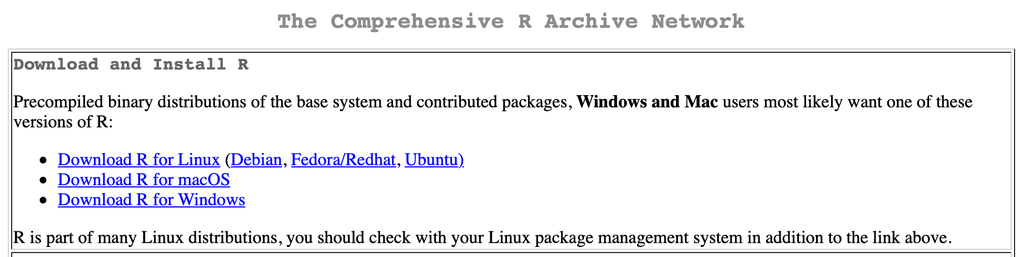

## Un IDE para R

- Podemos utilizar R ejecutando nuestro código directamente desde documentos de texto plano.
- Un IDE nos proporciona herramientas para escribir y revisar nuestro código, administrar los archivos que estamos usando, gestionar nuestro entorno de trabajo y algunas otras herramientas de productividad.
- Hay varias opciones de IDE para R.

## Consolas en línea

[figure not shown]

## R Studio

- RStudio es desarrollado por un equipo que ha contribuido de manera significativa para lograr que R sea lenguaje de programación más accesible, con un énfasis en la colaboración y la reproducción de los análisis.
- Permite un análisis y desarrollo para que cualquiera pueda analizar los datos con R.

## Instalar R Studio

Para instalar RStudio, es necesario con descargar y ejecutar alguno de los instaladores disponibles en su sitio oficial https://www.rstudio.com/products/rstudio/download/

[figure not shown]

## Conceptos básicos

## Consola de R

- Corresponde al entorno computacional de este lenguaje.
- Es aquí donde nuestro código es interpretado.

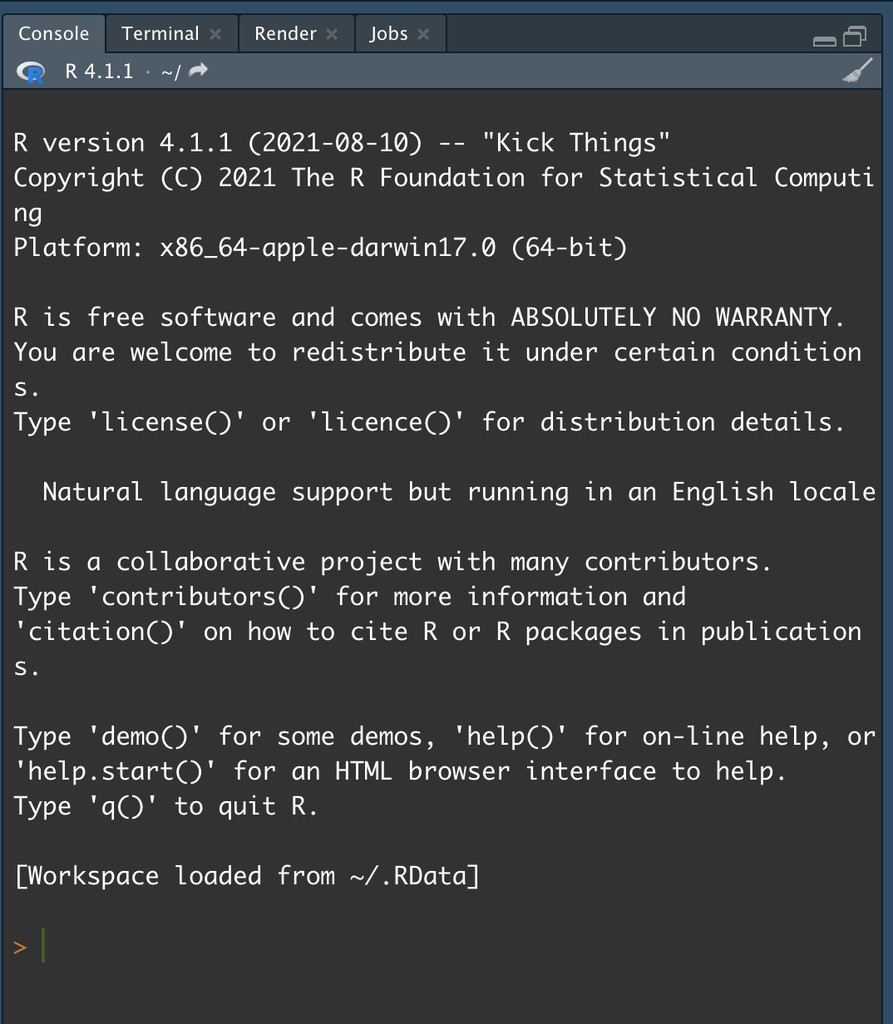

## R como calculadora

Podemos escribir código directamente en la consola

```r
3*5
```

```
## [1] 15
```

```r
12.3/2.6
```

```
## [1] 4.730769
```

```r
cos(0)
```

```
## [1] 1
```

## Variables

- En R usamos *<-* o *=* para hacer asignaciones o definir *variables*.
- Utilizamos *#* para escribir comentarios.

```r
a <- 3*5
a
```

```
## [1] 15
```

```r
b = 2+6; b
```

```
## [1] 8
```

```r
# Comentario
```

## Funciones

- Una función es una serie de operaciones a la que les hemos asignados un nombre.
- En R reconocemos a una función usando la notación: *nombre_de_la_función()*

```r
cos(0)
```

```
## [1] 1
```

```r
sqrt(4)
```

```
## [1] 2
```

```r
sin( pi )
```

```
## [1] 1.224647e-16
```

## Documentación

- Para saber como trabajar con una función pordemos ver su *documentación*.
- La documentación describe qué hace la función, sus argumentos, detalles sobre las operaciones que realiza,los resultados que devuelve y ejemplos de uso.

```r
?pnorm(1.75)
help("pnorm")
```

## R orientado a objetos

- En R, todo es un objeto.
- Todos los datos y estructuras de datos son objetos.
- Todos los objetos tienen un nombre para identificarlos.

## ¿Cómo funciona R?

Estructura de datos en R.

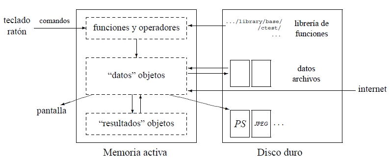

## Tipos de datos

## Estructura de datos

Las estructuras de datos en R se organizan por:

```
- Dimensionalidad y
- Homogeneidad o heterogeneidad.
```

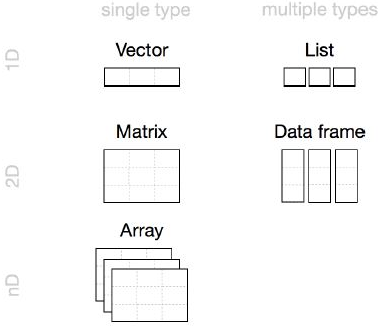

## Vectores

- Los elementos de un vector son del mismo tipo.
- Un vector es creado mediante la función combinar *c( )*.

```r
a = 3
vec = c(1,a)
vec
```

```
## [1] 1 3
```

## Tipos de Vectores

Vector double:

```r
dbl_vec <- c(3.5, 2, -1)
```

Vector entero: El sufijo L para crear un vector entero;

```r
int_vec <- c(3L, 7L, 1L)
```

## Tipos de Vectores

Vector caracter: Se usa ” para crear un vector texto ;

```r
chr_vec <- c("R", "Users", "Group")
```

Vector lógico: Se utiliza TRUE y FALSE o T y F para crear un vector lógico.

```r
log_vec <- c(FALSE, TRUE, F, T)
```

## Elementos de un Vector

La componente *k* del objeto *vec* se obtiene mediante *vec[k]*.

```r
vec <- c(6, 1, 3, 6, 10, 5)
vec[5]
```

```
## [1] 10
```

Para seleccionar varios elementos utilizamos *vec[c(elementos)]*.

```r
vec[c(2, 4)]
```

```
## [1] 1 6
```

## Elementos de un vector

Para omitir el elemento *k* de vec se utiliza *vec[-k]*.

```r
vec[-5]
```

```
## [1] 6 1 3 6 5
```

## Generación de vectores como sucesiones

El operador *a:b* genera el vector \(a, a+1, a+2, \ldots , b\).

```r
1:10
```

```
##  [1]  1  2  3  4  5  6  7  8  9 10
```

```r
5:-5
```

```
##  [1]  5  4  3  2  1  0 -1 -2 -3 -4 -5
```

## Generación de vectores como sucesiones

La función seq( ) genera secuencias controlando: inicio, fin y salto.

```r
seq(from = 1, to = 5, by = 0.5)
```

```
## [1] 1.0 1.5 2.0 2.5 3.0 3.5 4.0 4.5 5.0
```

## Matrices

Una matriz es un vector con el atributo dimensión dim. El atributo dim es un vector de longitud *2:c(nrow, ncol)*. Se construye por columnas por defecto *(byrow=FALSE)*.

```r
mtx <- matrix (1:12,nrow=3, ncol=4, byrow=FALSE)
mtx
```

```
##      [,1] [,2] [,3] [,4]
## [1,]    1    4    7   10
## [2,]    2    5    8   11
## [3,]    3    6    9   12
```

## Listas

Una lista es un vector que puede contener elementos de cualquier tipo y de distinta longitud.

Para crear una lista se utiliza la función *list()* en lugar de *c()*.

```r
lst <- list(c(1, 2), c(TRUE), c("a", "b", "c"))
lst
```

```
## [[1]]
## [1] 1 2
##
## [[2]]
## [1] TRUE
##
## [[3]]
## [1] "a" "b" "c"
```